# Rosyjskie szlaki handlowe

Marcin Wilczyński

17 stycznia 2019

## Wczytywanie danych

Dane pobrano z http://tuvalu.santafe.edu/~aaronc/data/russiantrade.zip. Dotyczą one sieci szlaków handlowych w średniowiecznej Rosji. Wierzchołki grafu przedstawiają miasta, a krawędzie drogi między nimi. Krawędzie nie posiadają wag. Dane w pliku mają postać listy krawędzi.

```r
raw_data <- read.csv("data//russiantrade_edges.txt", sep = "\t", header = FALSE)
head(raw_data)
```

```
##   V1 V2
## 1  1  2
## 2  1 15
## 3  2  3
## 4  3  4
## 5  3 11
## 6  4  5
```

## Biblioteka

Do analizy grafu wykorzystano bibliotekę igraph. Porównanie grafu z pliku z materiałem źródłowym (załączonym przez autorów do pliku z danymi) ukazało pojedyncze brakujące krawędzie. Zostały dodane do źródłowego pliku.

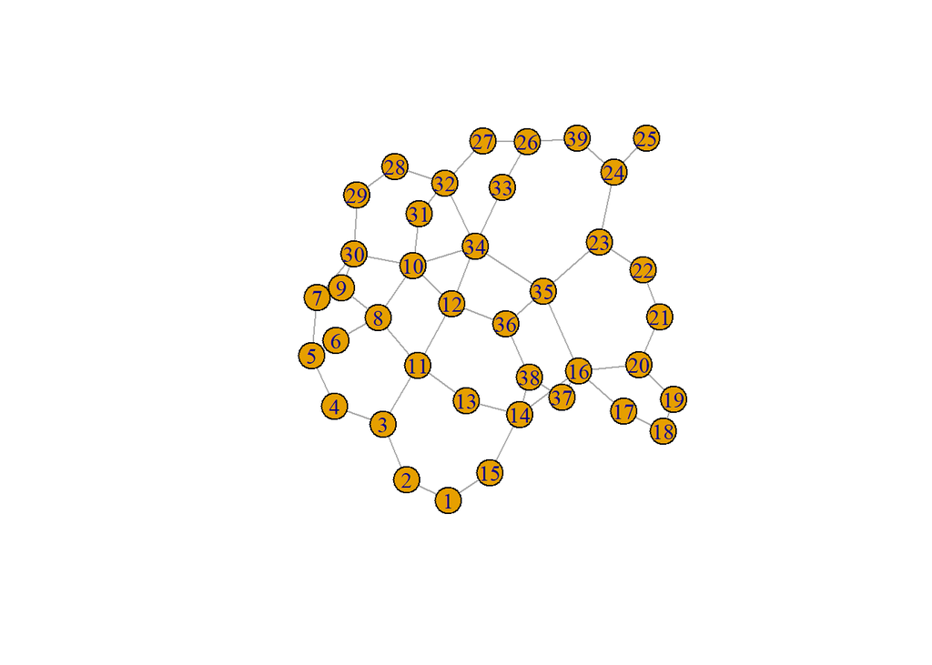

```r
library(igraph)
net <- graph.data.frame(raw_data,directed=FALSE)
l <-layout.auto(net)
plot(net, layout = l)
```

## Charakterystyka zbioru danych

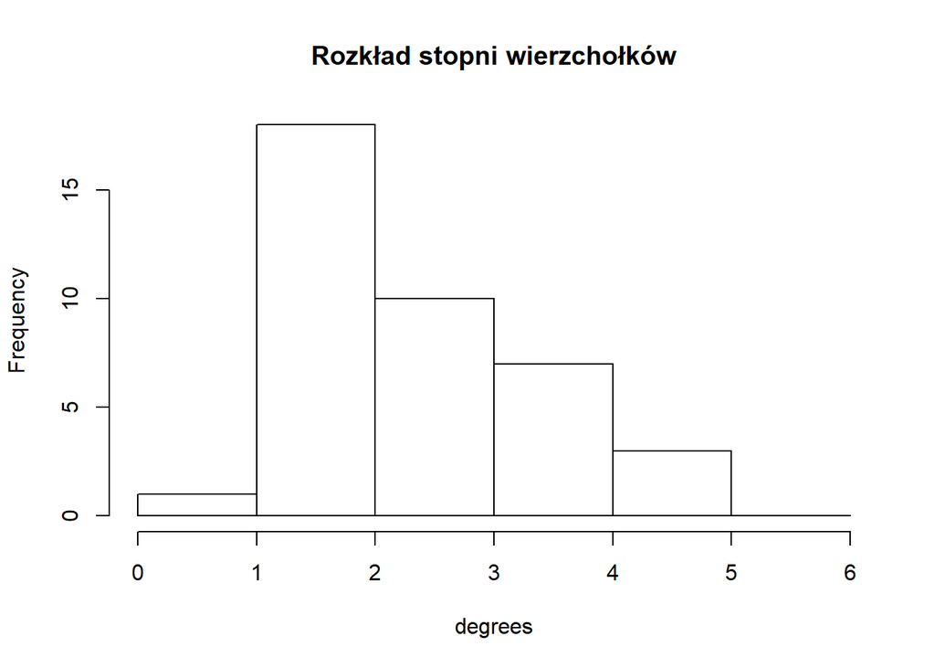

```r
degrees <- degree(net)
hist(degrees, breaks = 0:6, main = "Rozkład stopni wierzchołków")
```

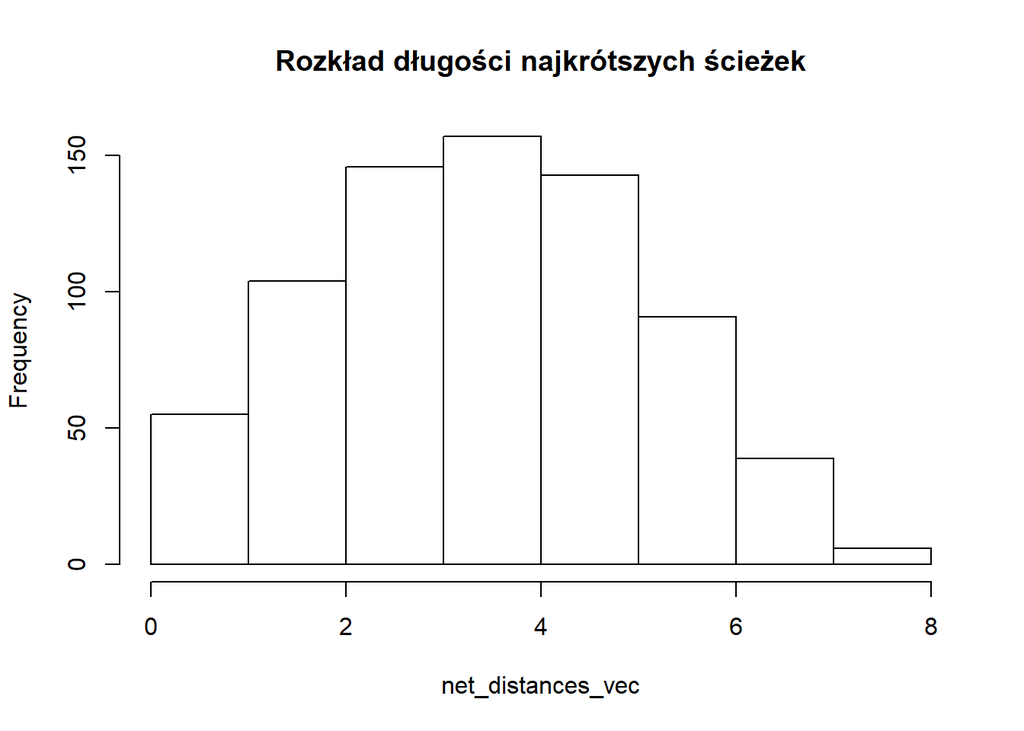

```r
net_distances <- distances(net)
net_distances[lower.tri(net_distances)] <- 0
net_distances_vec <- as.vector(net_distances)
net_distances_vec <- net_distances_vec[net_distances_vec>0]
hist(net_distances_vec, breaks = 0:8, main = "Rozkład długości najkrótszych ścieżek")
```

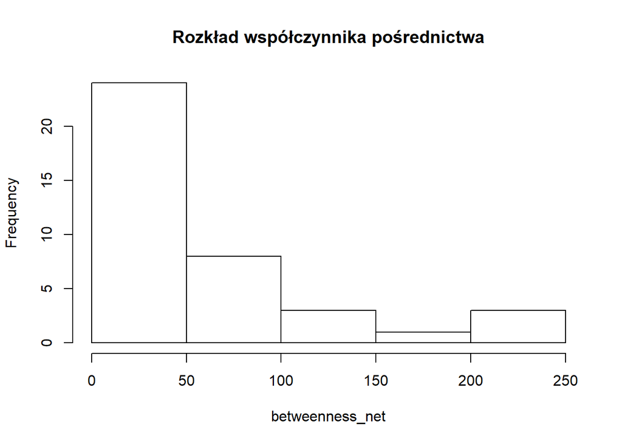

```r
betweenness_net <- betweenness(net)
hist(betweenness_net, main = "Rozkład współczynnika pośrednictwa")
```

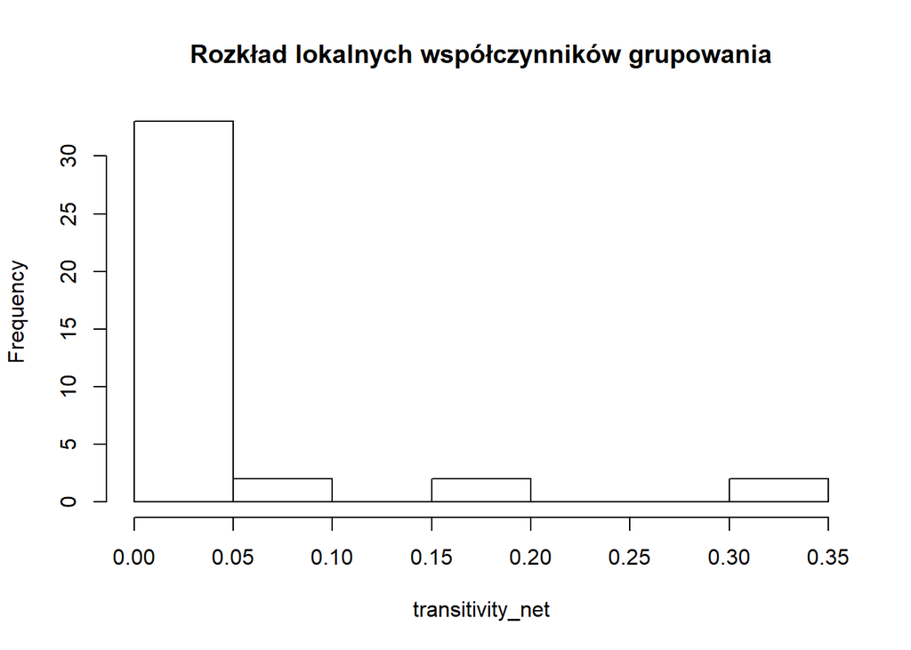

```r
transitivity_net = transitivity(net, type="local", isolates="zero")
hist(transitivity_net, main = "Rozkład lokalnych współczynników grupowania")
```

```r
density_net <- edge_density(net)
diameter_net <- diameter(net)
centralization_net <- centr_degree(net, mode="total")$centralization
```

## Pytania biznesowe

### Główny magazyn

Klient, średniowieczny kupiec, szuka miejsca na główny magazyn. Analityk zasugerował mu wybudowanie go w jednej z miejscowości o największym współczynniku pośrednictwa, ponieważ jest to miejsce przez które przechodzi najwięcej najkrótszych ścieżek pomiędzy innymi miejscowościami.

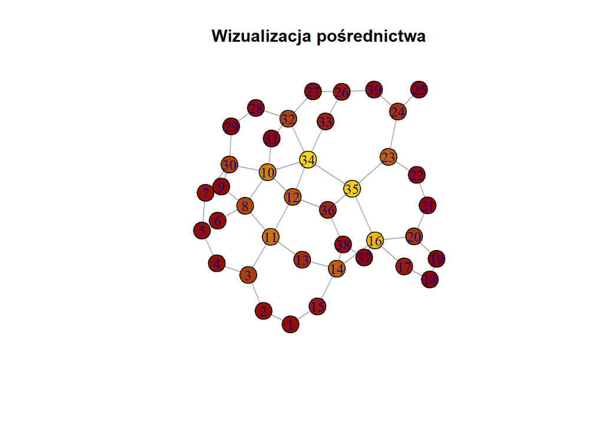

```r
oranges <- colorRampPalette(c("dark red", "gold"))
betweenness_net <- betweenness(net)
fine = 500
graphCol = oranges(fine)[as.numeric(cut(betweenness_net,breaks = fine))]
plot(net, vertex.color=graphCol, layout = l)
title(main = "Wizualizacja pośrednictwa")
```

Analityk zaproponował również aby klient wziął pod uwagę bliskość jako interesujący wskaźnik. Pomoże on znaleźć miejscowość, z której jest średnio najbliżej do wszystkich innych miejscowości.

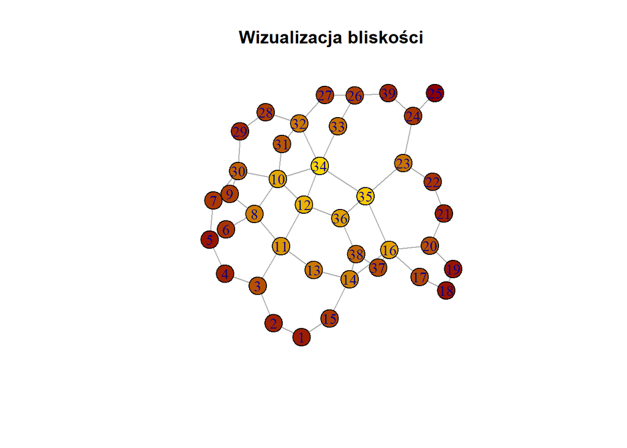

```r
oranges <- colorRampPalette(c("dark red", "gold"))
closeness_net <- closeness(net, normalized = TRUE)
fine = 500
graphCol = oranges(fine)[as.numeric(cut(closeness_net,breaks = fine))]
plot(net, vertex.color=graphCol, layout = l)
title(main = "Wizualizacja bliskości")
```

### Najdłuższa możliwa trasa

Dla klienta kluczowym parametrem jest minimalizacja liczby miast, które pokonuje aby przetransportować towar z miasta A do B. Zadał zatem pytanie analitykowi o najdłuższą pod względem liczby odwiedzonych miast, najkrótszą trasę pomiędzy dowolnymi dwoma miastami.

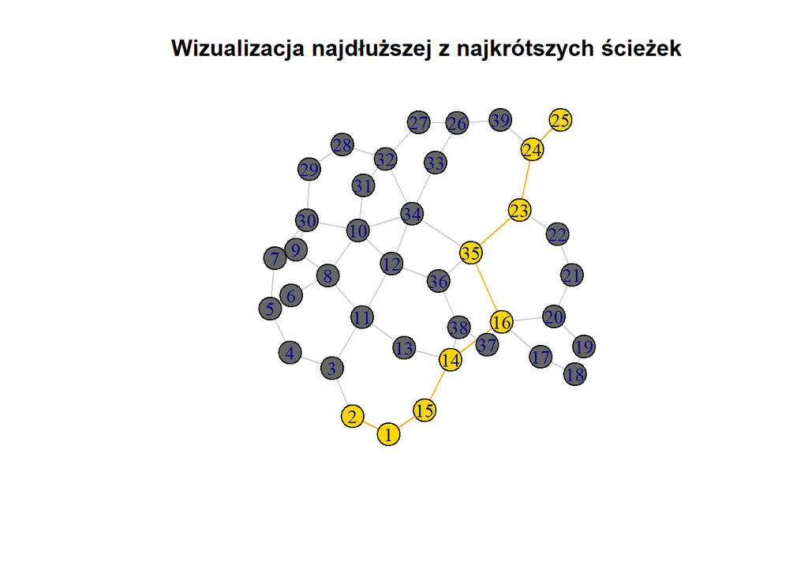

```r
diam <- get_diameter(net)
vcol <- rep("gray40", vcount(net))
vcol[diam] <- "gold"
ecol <- rep("gray80", ecount(net))
ecol[E(net, path=diam)] <- "orange"
plot(net, vertex.color=vcol, edge.color=ecol, layout = l)
title(main = "Wizualizacja najdłuższej z najkrótszych ścieżek")
```